# Qtip

Gregg Thomas

## Example read sets

Read set 1

| Reads | A A A A A A A A A A A A A A A A A A A A |
| --- | --- |
| Base qual | 40 40 40 40 40 40 40 40 40 40 40 40 40 40 40 40 40 40 40 1-40 |
| Map qual | 40 40 40 40 40 40 40 40 40 40 40 40 40 40 40 40 40 40 40 1-40 |

Read set 2

| Reads | A A A A A A A A A A A A A A A A A A A T |
| --- | --- |
| Base qual | 40 40 40 40 40 40 40 40 40 40 40 40 40 40 40 40 40 40 40 1-40 |
| Map qual | 40 40 40 40 40 40 40 40 40 40 40 40 40 40 40 40 40 40 40 1-40 |

Read set 3

| Reads | A A A A A A A A A A T T T T T T T T T T |
| --- | --- |
| Base qual | 40 40 40 40 40 40 40 40 40 40 40 40 40 40 40 40 40 40 40 1-40 |
| Map qual | 40 40 40 40 40 40 40 40 40 40 40 40 40 40 40 40 40 40 40 1-40 |

## I. Genotype likelihoods and quality scores (briefly)

$$\mathbb{G} = \{\{A,A\}, \{A,T\}, \{A,C\}, \{A,G\}, \{T,T\}, \{T,C\}, \{T,G\}, \{C,C\}, \{C,G\}, \{G,G\}\}$$

Given a set of reads $R$ at a site, we can calculate the likelihood of each genotype.

**Equation 1**

$$P(R|\mathbb{G} = \{A_1,A_2\}) = \prod_{r}^{R} (\frac{1}{2}P(b_r|A_1) + \frac{1}{2}P(b_r|A_2) )$$

To calculate the probability of the mapped base at the current read $b_r$ given each allele in the genotype $A_i$, we can use the Phred scaled base quality score $Q_b$ and Phred scaled mapping quality score $Q_m$ for that base. First we convert the Phred scale scores into probabilities of error:

**Equation 2**

$$e = 10^{-\frac{Q}{10}}$$

Plugging in $Q_b$ and $Q_m$ gets us $e_b$ and $e_m$, respectively. These are the probabilities of error for both base calling and mapping.

Then we can calculate the probability of the base given an allele $P(b_r|A_i)$ as follows:

**Equation 3**

$$\begin{equation}
P(b_r|A_i) =
\begin{cases}
\frac{(e_s * e_m)}{3} & \text{: $b \neq A_i$}\\
1 - (e_s * e_m) & \text{: $b = A_i$}\\
\end{cases}
\end{equation}$$

The likelihood of each genotype is obtained in this fashion. These likelihoods are then converted back to the Phred scale:

**Equation 4**

$$PL = -10 \log_{10}(P(R|\mathbb{G} = \{A_1,A_2\}))$$

Since these are likelihoods that the genotype is incorrect, the lowest likelihood is the best scoring. This translates to $PL$ as well. Therefore, we obtain a genotype quality score $Q_\mathbb{G}$ by taking the difference between the lowest score and the second lowest score.

**Equation 5**

$$Q_\mathbb{G} = min_2(PL) - min(PL)$$

## II. A reference quality score

Now we wish to compute a similar value for a reference base given a set of reads that map to that position $Q_{ref}$. The general behavior we want for this score is that it will be high when we are sure the reference base is correct (as in Read Sets 1 and 2 with reference base A; see Example read sets at top of page) and low when we are sure the reference base is incorrect (as in Read Sets 1 and 2 with reference base T or C; see Example read sets at top of page)

First, we sum up the likelihoods of all genotypes that contain the reference allele ($L_{match}$) and separately sum up the likelihoods of all the genotypes that do not contain the reference allele ($L_{mismatch}$). For instance, if our reference base was an A, then:

$$L_{match} = P(R|\{A,A\}) + P(R|\{A,T\}) + P(R|\{A,C\}) + P(R|\{A,G\})$$

and:

$$L_{mismatch} = P(R|\{T,T\}) + P(R|\{T,C\}) + P(R|\{T,G\}) + P(R|\{C,C\}) + P(R|\{C,G\}) + P(R|\{G,G\})$$

**Equation 8**

$$LR = \frac{L_{mismatch}}{L_{match}}$$

**Figure 2: Examples of $Q_{ref}$**

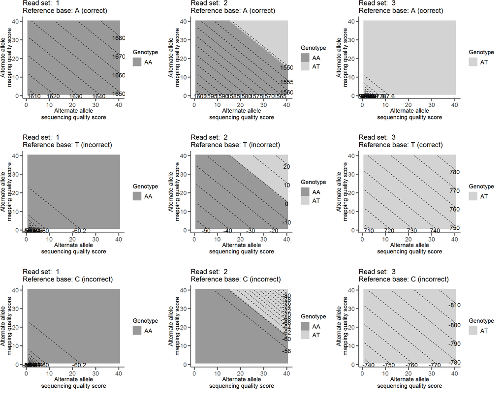

Scores at max base and mapping quality

| read_set | ref_base | ref_type | genotypes | gt_quality | alt_base_quality | alt_map_quality | ref_quality |
| --- | --- | --- | --- | --- | --- | --- | --- |
| 1 | A | (correct) | AA | 60.20600 | 40 | 40 | 1687.64275 |
| 2 | A | (correct) | AT | 24.56521 | 40 | 40 | 1547.45189 |
| 3 | A | (correct) | AT | 787.50613 | 40 | 40 | 787.49765 |
| 1 | T | (incorrect) | AA | 60.20600 | 40 | 40 | -60.20601 |
| 2 | T | (incorrect) | AT | 24.56521 | 40 | 40 | 24.56520 |
| 3 | T | (correct) | AT | 787.50613 | 40 | 40 | 787.49765 |
| 1 | C | (incorrect) | AA | 60.20600 | 40 | 40 | -60.20601 |
| 2 | C | (incorrect) | AT | 24.56521 | 40 | 40 | -81.77607 |
| 3 | C | (incorrect) | AT | 787.50613 | 40 | 40 | -814.59883 |

Scores at min base and mapping quality

|  | read_set | ref_base | ref_type | genotypes | gt_quality | alt_base_quality | alt_map_quality | ref_quality |
| --- | --- | --- | --- | --- | --- | --- | --- | --- |
| 1600 | 1 | A | (correct) | AA | 58.24727 | 1 | 1 | 1605.31352 |
| 16001 | 2 | A | (correct) | AA | 55.80529 | 1 | 1 | 1601.89704 |
| 16002 | 3 | A | (correct) | AT | 707.13562 | 1 | 1 | 789.45156 |
| 16003 | 1 | T | (incorrect) | AA | 58.24727 | 1 | 1 | -58.24728 |
| 16004 | 2 | T | (incorrect) | AA | 55.80529 | 1 | 1 | -55.80530 |
| 16005 | 3 | T | (correct) | AT | 707.13562 | 1 | 1 | 707.12715 |
| 16006 | 1 | C | (incorrect) | AA | 58.24727 | 1 | 1 | -58.24728 |
| 16007 | 2 | C | (incorrect) | AA | 55.80529 | 1 | 1 | -57.19572 |
| 16008 | 3 | C | (incorrect) | AT | 707.13562 | 1 | 1 | -737.23862 |

## III. Preliminary testing on old simulated *C. elegans* assembly

I quickly implemented the above method in Python and used the old simulated *C. elegans* assembly from the RPGC project to test.

Here are some statistics about that assembly:

| Description | Value |
| --- | --- |
| Scaffolds | 212 |
| Bases | 99265117 |
| Mapped sites with ANGSD calcs | 96250753 |
| Sites with Qtip scores | 96250753 |
| QTip run time | 57.2 minutes |
| Sites with $L_{unmatch}$ = 0 | 8168 |
| Sites with $L_{match}$ = 0 | 0 |
| Sites with ref base N | 1179 |
| Max Qtip score | 3233 |
| Min Qtip score | -858 |
| Mean Qtip score | 325.62 |
| Standard deviation of Qtip scores | 165.71 |

**Figure 3: Distribution of QTip scores with many vertical lines on *C. elegans* data**

Dashed line = mean Thick dotted lines = mean +/- 1 sd Thin dotted lines = mean +/- 2 sd

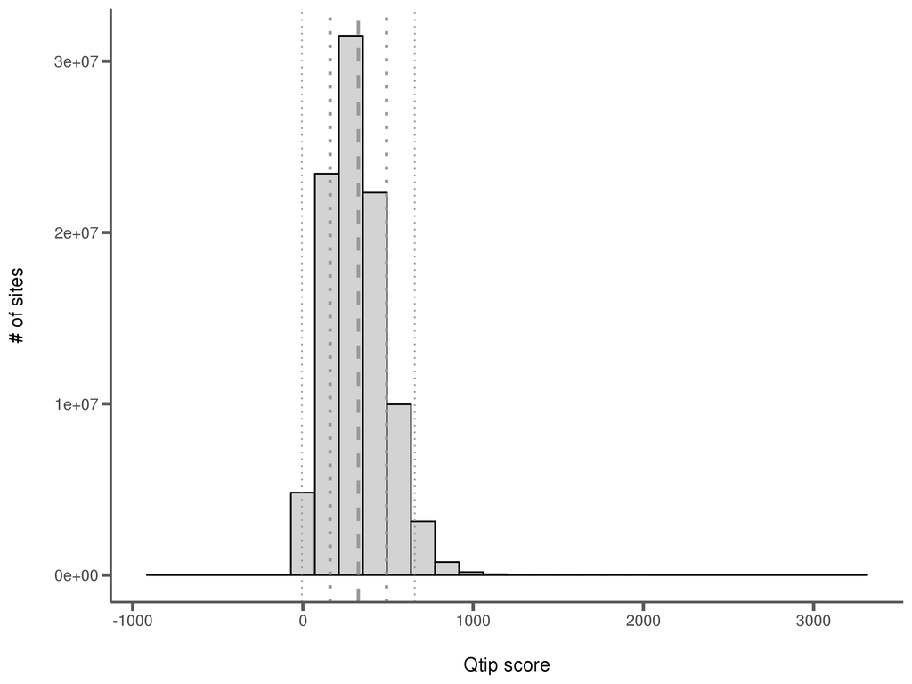

**Figure 4: Distribution of QTip scores with many vertical lines on *C. elegans* data limiting to scores between -100 and 1200**

Dashed line = mean Thick dotted lines = mean +/- 1 sd Thin dotted lines = mean +/- 2 sd

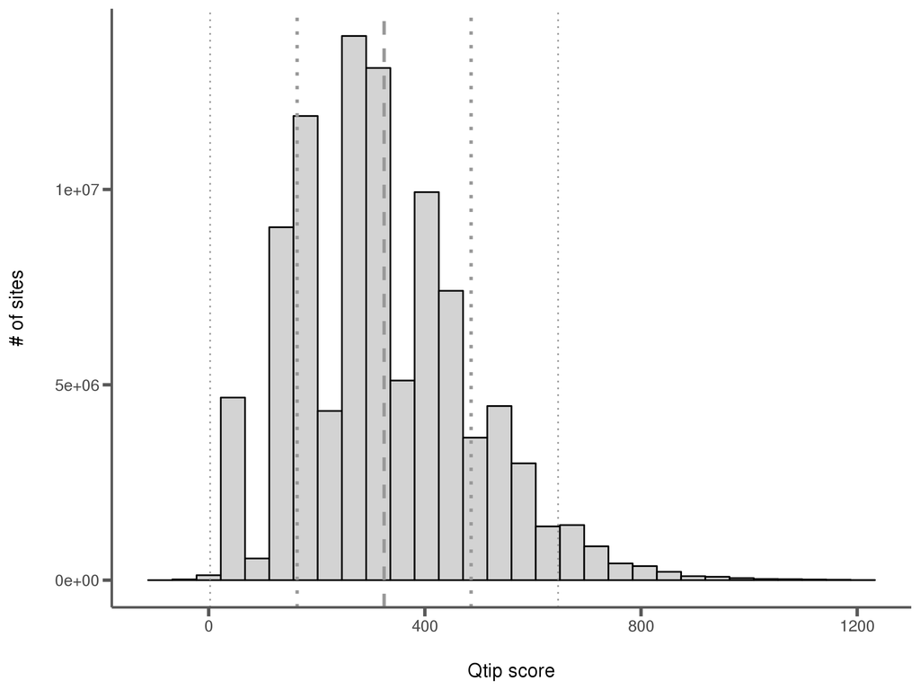

## IV. Questions and concerns moving forward

1. Inputs are (1) A reference FASTA and (2) the genotype likelihood calculations file from ANGSD (http://www.popgen.dk/angsd/index.php/ANGSD) from option -doGlf 4. The first file is 100.5 MB and the second file is 1.4 GB compressed for the *C. elegans* data.
2. How many ways do we want to have input files specified? To parallelize based on input:
- If a FASTA with only 1 scaffold is input, split that file into chunks.
- If a FASTA with multiple scaffolds is input, split by scaffold.
- If multiple FASTA files are input, split by file.
3. Output is currently a file with one line per site containing the scaffold, position, and qtip score rounded to nearest integer and is 2.1 GB in size. This is simple, but is there other info we should include? If we do FASTQ format, we will definitely need to scale the scores somehow, since there are only 93 usable ASCII characters (https://en.wikipedia.org/wiki/FASTQ_format) and we have thousands of scores to represent.
- One option is to change the scaling from $-10\log{LR}$ to $-1 \log{LR}$. This would put most scores between 0 and 90 for this test dataset. I’m not sure that range will hold true for larger genomes.
4. How should we score the following cases:

| Scenario | Currently scored as |
| --- | --- |
| $L_{match}$ = 0 | -9999 |
| $L_{unmatch}$ = 0 | 9999 |
| Reference base = N | -9998 |
| No reads mapped to site | N/A |

5. If the Qtip score < 0, or the reference base is N, should we suggest a correct base?
6. Regardless of whether we do FASTQ output, should the scores be normalized? How?
7. ANGSD does NOT consider mapping quality in calculating genotype likelihoods as far as I can tell. Does this matter?
8. The ANGSD likelihoods reported are log likelihoods, and then scaled so that they subtract the maximum score from each score (much like GATK does). Its easy enough to un-log the scores, but there is no way to reverse the scaling. This results in the highest scoring genotype having a likelihood of 1. Does this matter? I don’t think it does?
- The authors of ANGSD have pointed out that the scaling can be disabled by removing a chunk of code (https://github.com/ANGSD/angsd/issues/183). Conceivably, we could package our own version of ANGSD without this block of code, but that might be excessive.